# Homework 7

Импортируем пакеты:

```r
library(dplyr)
library(tidyr)
library(ggplot2)
library(googlesheets4)
library(ggrepel)
library(lubridate)
```

Загружаем данные из google-таблиц:

```r
# Каталог метеостанций:
metcatalog <- read_sheet('1InNM-zQbdhSlw1zmQPf9lPJvVr8waTqOq3G3Li6v4MU')
```

```
The googlesheets4 package is requesting access to your Google account.
Select a pre-authorised account or enter '0' to obtain a new token.
Press Esc/Ctrl + C to cancel.
```

```
1: ivan.solonikov@gmail.com
```

```r
1
```

```
Auto-refreshing stale OAuth token.
✔ Reading from Meteostations.
✔ Range Лист1.
```

```r
# Получаем индексы интересующих метеостанций:
indices <- metcatalog |>
              filter(NAME == 'Москва (центр, Балчуг)' |
                     NAME == 'Малое Сареево') |>
           pull(ID) |>
           as.character()
```

Создаём датафрейм

```r
# Читаем данные о погоде с метеостанций. Так как данные в таблице разбиты по
# вкладкам, каждая из которых соответствует отдельной метеостанции и названа её
# индексом, то читаем данные с помощью lapply, применяя функцию read_sheet к
# вектору индексов

df <- lapply(indices, read_sheet,
       ss = '1EHvMAuUoMtNbMzRCyOVZU81nB9yK48x7rpH2Rp56jrw',
       col_types = 'ccccccnnnnncnnnnnnn') |>
  rlang::set_names(indices) |>
  bind_rows(.id = 'ID') |>
  mutate(ID = as.numeric(ID),
         Datetime = as.POSIXct(Datetime)) |>
  # присоединяем датафрейм с информацией о метеостанциях:
  left_join(y = metcatalog, by = 'ID') |>
  # устанавливаем короткие имена колонок:
  rlang::set_names(c('ID', 'Datetime', 'Wdir', 'Wspd', 'Vis', 'Phen', 'Cloud',
                     'T', 'Td', 'F', 'Te', 'Tes', 'Comf', 'P', 'Po', 'Tmin',
                     'Tmax', 'R', 'R24', 'S', 'Name', 'Lon', 'Lat', 'H')) |>
  # В колонке со скоростями ветра есть строки вида "число{число}". Очевидно, что
  # число до фигурных скобок является средним за период данного наблюдения
  # значением скорости ветра, поэтому во избежание потери информации при
  # преобразовании к численному типу извечём часть строки до фигурных скобок:
  mutate(Wspd = stringr::str_extract(Wspd, '\\d*') |> as.numeric())
```

```
✔ Reading from Meteoarchive.
✔ Range ''27518''.
✔ Reading from Meteoarchive.
✔ Range ''27605''.
```

Создаём ночной датафрейм

```r
df_night <- df |>
                filter(hour(Datetime) == 3 |
                       hour(Datetime) == 0)
```

Строим функции распределения температур и диаграммы размаха (боксплоты), на которых сравним данные по двум метеостанциям. Сперва строим шаблон графика:

```r
dens_template <- ggplot() +
  geom_density(aes(x = T, fill = Name), alpha = 0.5, linewidth = .2) +
  labs(x = 'Температура', y = 'Плотность распределения', fill = 'Метеостанция')
```

Применяем шаблон к общему набору даннных:

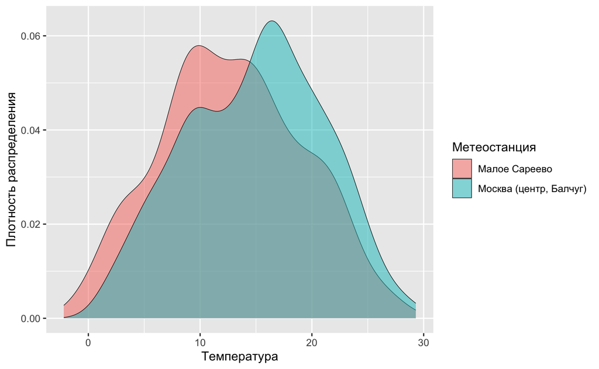

```r
dens_template + list(df)
```

Теперь строим график по ночным данным:

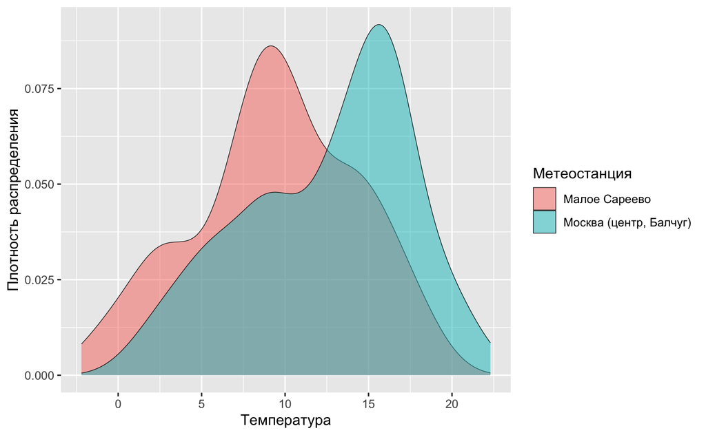

```r
dens_template + list(df_night)
```

На ночном графике отчётливо видно влияние городского острова тепла, так как максимум функции плотности распределения наблюдается при температуре на несколько градусов большей, чем на станции, расположенной в пригороде. На дневном графике закономерность также видна, но в меньшей степени.

Построим боксплоты. Шаблон боксплота:

```r
box_template <- ggplot() +
                  geom_boxplot(aes(x = T, y = Name)) +
                  labs(x = 'Температура', y = 'Метеостанция') +
                  theme_bw()
```

По общему набору данных:

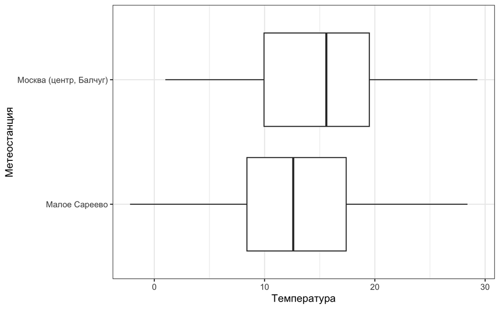

```r
box_template + list(df)
```

По ночным данным:

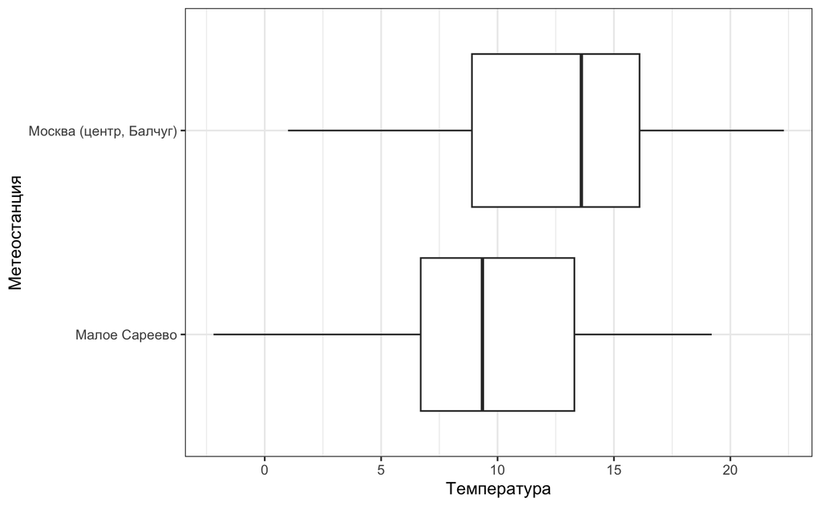

```r
box_template + list(df_night)
```

На боксплотах также видно влияние городского острова тепла: медианные температуры на обоих графиках выше для городской метеостанции, в ночной период различия выражены сильнее. Кроме того, для пригородной метеостанции характерен слегка больший размах вариации при меньшем, чем у городской станции межквартильном размахе. Распределение на ночном графике по пригородной станции асимметричное (что следует из асимметрии “усов” боксплота).

Сравним средние значения и дисперсии температур с помощью тестов Стьюдента и Фишера. Тест Стьюдента (Уэлча) по общей выборке:

```r
t.test(df |> filter(Name == 'Москва (центр, Балчуг)') |> pull(T),
       df |> filter(Name == 'Малое Сареево') |> pull(T))
```

```
    Welch Two Sample t-test

data:  pull(filter(df, Name == "Москва (центр, Балчуг)"), T) and pull(filter(df, Name == "Малое Сареево"), T)
t = 5.9192, df = 1289.4, p-value = 4.141e-09
alternative hypothesis: true difference in means is not equal to 0
95 percent confidence interval:
 1.372246 2.732770
sample estimates:
mean of x mean of y
 14.87975  12.82724
```

Средее значение температуры на городской метеостанции примерно на 2ºC выше, чем на пригородной; p-значение очень мало, что позволяет принять (не отвергать) гипотезу о неравенстве средних. Тест Фишера по общей выборке:

```r
var.test(df |> filter(Name == 'Москва (центр, Балчуг)') |> pull(T),
       df |> filter(Name == 'Малое Сареево') |> pull(T))
```

```
    F test to compare two variances

data:  pull(filter(df, Name == "Москва (центр, Балчуг)"), T) and pull(filter(df, Name == "Малое Сареево"), T)
F = 0.93416, num df = 646, denom df = 645, p-value = 0.3871
alternative hypothesis: true ratio of variances is not equal to 1
95 percent confidence interval:
 0.8004847 1.0901436
sample estimates:
ratio of variances
         0.9341582
```

Различие дисперсий температуры на метеостанциях невелико (так как их отношение близко к единице) и статистически незначимо (высокое p-значение).

Проверим ночную выборку. Тест Стьюдента (Уэлча) по ночной выборке:

```r
t.test(df_night |> filter(Name == 'Москва (центр, Балчуг)') |> pull(T),
       df_night |> filter(Name == 'Малое Сареево') |> pull(T))
```

```
    Welch Two Sample t-test

data:  pull(filter(df_night, Name == "Москва (центр, Балчуг)"), T) and pull(filter(df_night, Name == "Малое Сареево"), T)
t = 5.6303, df = 321.97, p-value = 3.92e-08
alternative hypothesis: true difference in means is not equal to 0
95 percent confidence interval:
 1.997513 4.143228
sample estimates:
mean of x mean of y
12.502469  9.432099
```

```r
var.test(df_night |> filter(Name == 'Москва (центр, Балчуг)') |> pull(T),
       df_night |> filter(Name == 'Малое Сареево') |> pull(T))
```

```
    F test to compare two variances

data:  pull(filter(df_night, Name == "Москва (центр, Балчуг)"), T) and pull(filter(df_night, Name == "Малое Сареево"), T)
F = 1.0208, num df = 161, denom df = 161, p-value = 0.8961
alternative hypothesis: true ratio of variances is not equal to 1
95 percent confidence interval:
 0.7487052 1.3918731
sample estimates:
ratio of variances
          1.020834
```

Различие дисперсий ночной температуры на метеостанциях практически отсутствует (так как их отношение примерно равно единице) и статистически незначимо (высокое p-значение).

Получим датафрейм, в котором на каждый временной срез имеется разность температур между городской и загородной метеостанцией, а также средняя по всем метеостанциям (средняя по региону) скорость ветра.

Сперва получим датафрейм со средними по региону скоростями ветра:

```r
# Получаем имена всех листов таблицы с метеоданными (каждый лист соответствует
# отдельной метеостанции):
winddata <- sheet_names('1EHvMAuUoMtNbMzRCyOVZU81nB9yK48x7rpH2Rp56jrw') |>
  # преобразуем в именованный вектор, в котором и сами элементы, и их имена --
  # это индексы метеостанций. Это нужно для того, чтобы дальше при склейке
  # списка датафреймов в один датафрейм в колонке ID был индекс станции:
  rlang::set_names() |>
  # читаем данные по всем метеостанциям:
  lapply(read_sheet,
         ss = '1EHvMAuUoMtNbMzRCyOVZU81nB9yK48x7rpH2Rp56jrw',
         # уточняем колонки, чтобы не считывать всё полностью; индекс 2
         # позволяет считывать начиная со второй строчки (в первой строчке
         # содержатся заголовки):
         range = 'A2:C',
         col_names = c('Datetime', 'Wdir', 'Wspd'),
         col_types = 'c_c') |>
  # склеиваем в один датафрейм:
  bind_rows(.id = 'ID') |>
  # выбираем из колонки со скоростью ветра только числа без дополнительной
  # информации, чтобы не получить NA при преобразовании к численному типу;
  # дату преобразуем к POSIXct из строкового типа
  mutate(
    ID = as.numeric(ID),
    Datetime = as.POSIXct(Datetime),
    Wspd = stringr::str_extract(Wspd, '\\d*') |> as.numeric())
```

[output not shown]

Обобщим данные о скорости ветра по разным метеостанциям, чтобы получить среднее по региону:

```r
region_wind <- winddata |>
  group_by(Datetime) |>
  summarize(RegWspd = mean(Wspd))
```

Итоговый датафрейм с разностями температур и средними по региону скоростями ветра:

```r
df_TW <- df |>
  select(Name, Datetime, T) |> # выбираем только нужные колонки
  pivot_wider(names_from = Name, # приводим к широкому виду из длинного
              values_from = T) |>
  # вычисляем разность температур по каждому временному срезу:
  transmute(Datetime = Datetime,
            dT = `Москва (центр, Балчуг)` - `Малое Сареево`) |>
  # добавляем данные о скорости ветра
  inner_join(y = region_wind, by = 'Datetime') |>
  na.omit()
```

Ночная версия этого датафрейма:

```r
df_TW_night <-  df_TW |>
  filter(hour(Datetime) == 3 |
         hour(Datetime) == 0)
```

Построим диаграммы рассеяния между скоростью ветра и разностью температур. Диаграмма рассеяния по всему датафрейму:

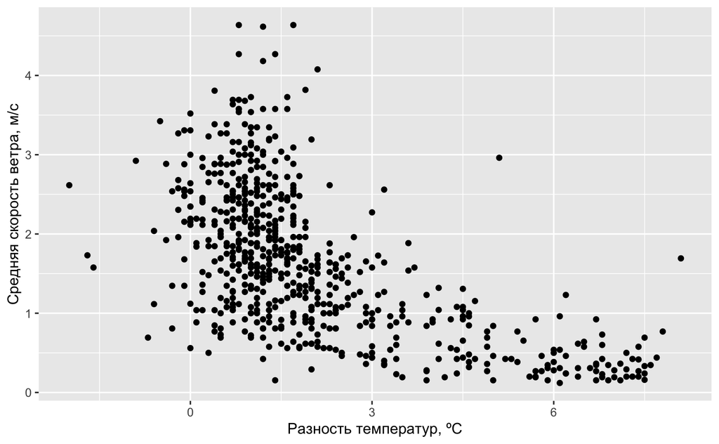

```r
ggplot(df_TW, aes(y = RegWspd, x = dT)) +
  geom_point() +
  xlab('Разность температур, ºC') +
  ylab('Средняя скорость ветра, м/с')
```

Диаграмма рассеяния по ночному датафрейму:

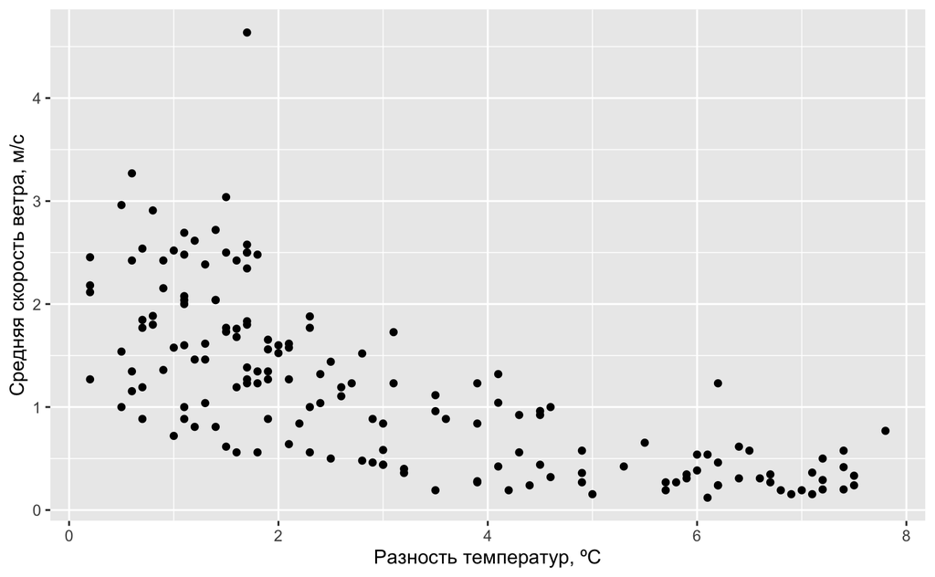

```r
ggplot(df_TW_night, aes(y = RegWspd, x = dT)) +
  geom_point() +
  xlab('Разность температур, ºC') +
  ylab('Средняя скорость ветра, м/с')
```

По графикам видна обратная связь между скоростью ветра и разностью температур: чем ниже скорость ветра, тем выраженнее эффект влияния острова тепла. При этом связь нелинейная – разность температур достаточно высока при средней скорости ветра ниже 1 м/с и по мере роста скорости резко снижается. На общем графике нелинейность выражена сильнее, во многом за счёт большего количества точек с высокой скоростью ветра, чем на ночном графике.

Попробуем привести зависимость к линейной с помощью преобразований и добавим на графики линию регрессии. По общему датафрейму:

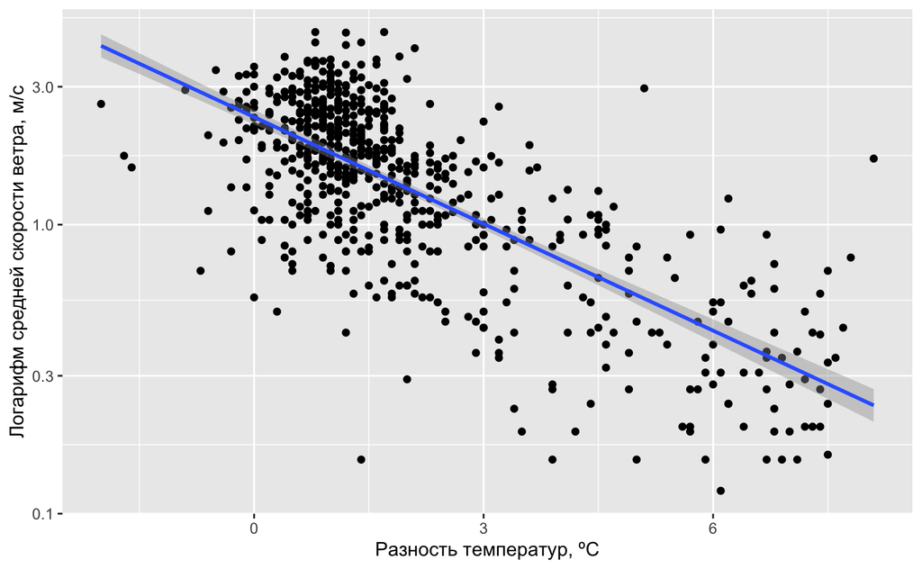

```r
ggplot(df_TW, aes(y = RegWspd, x = dT)) +
  geom_point() +
  geom_smooth(method = 'lm') +
  scale_y_log10() +
  xlab('Разность температур, ºC') +
  ylab('Логарифм средней скорости ветра, м/с')
```

По ночному датафрейму:

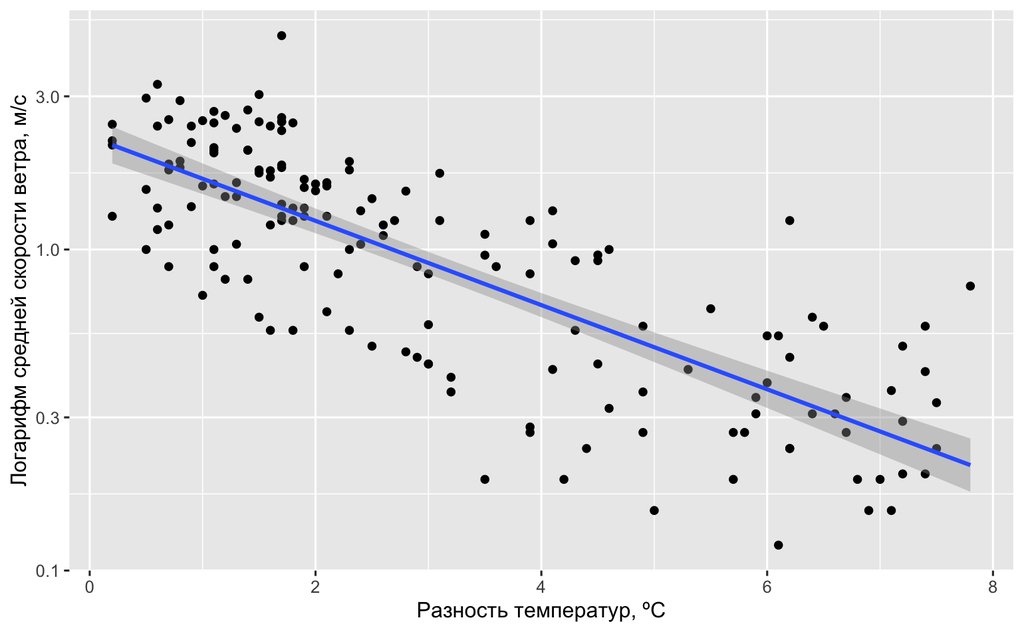

```r
ggplot(df_TW_night, aes(y = RegWspd, x = dT)) +
  geom_point() +
  geom_smooth(method = 'lm') +
  scale_y_log10() +
  xlab('Разность температур, ºC') +
  ylab('Логарифм средней скорости ветра, м/с')
```

Прологарифмировав значения скорости ветра, мы приблизили их связь со значениями разности температур к линейному виду. Связь обратная: разность температур и, соответственно, влияние эффекта острова тепла тем выше, чем меньше логарифм средней скорости ветра. На ночном графике связь весьма близка к линейной, а на общем графике при этом наблюдается концентрация точек в области высоких скоростей ветра и низких разностей температур. Таким образом, можно предположить, что влияние городского острова тепла более выражено в ночное время. Выполним корреляционный тест между разностью температур (y) и логарифмом скорости ветра (x). Для общей выборки:

```r
cor.test(x = log10(df_TW$RegWspd),
         y = df_TW$dT)
```

```
    Pearson's product-moment correlation

data:  log10(df_TW$RegWspd) and df_TW$dT
t = -27.112, df = 643, p-value < 2.2e-16
alternative hypothesis: true correlation is not equal to 0
95 percent confidence interval:
 -0.7644455 -0.6921740
sample estimates:
       cor
-0.7303472
```

Корреляционный тест подтверждает обратную связь величин: доверительный интервал (с вероятностью 0.95) коэффициента корреляции находится в диапазоне от -0.76 до -0.69, его математическое ожидание составляет -0.73. По ночной выборке:

```r
cor.test(x = log10(df_TW_night$RegWspd),
         y = df_TW_night$dT)
```

```
    Pearson's product-moment correlation

data:  log10(df_TW_night$RegWspd) and df_TW_night$dT
t = -16.251, df = 160, p-value < 2.2e-16
alternative hypothesis: true correlation is not equal to 0
95 percent confidence interval:
 -0.8409998 -0.7229076
sample estimates:
       cor
-0.7891385
```

Для ночной выборки обратная корреляция ещё более выражена: коэффициент корреляции с вероятностью 95% лежит в диапазоне от -0.84 до -0.72, его математическое ожидание составляет -0.79.

Построим модель линейной регрессии между скоростью ветра (x) и разностью температур (y), применив к x логарифмическое преобразование.

```r
# Для общей выборки:
my_mdl <- lm(dT ~ log10(RegWspd), data = df_TW)
# Для ночной выборки:
my_mdl_night <- lm(dT ~ log10(RegWspd), data = df_TW_night)
```

Коэффициенты моделей:

```r
# По общей выборке:
coef(my_mdl)
```

```
   (Intercept) log10(RegWspd)
      2.569162      -4.330993
```

```r
# По ночной выборке:
coef(my_mdl_night)
```

```
   (Intercept) log10(RegWspd)
      2.827442      -4.747321
```

Подробная сводка о качестве модели:

```r
summary(my_mdl)
```

```
Call:
lm(formula = dT ~ log10(RegWspd), data = df_TW)

Residuals:
    Min      1Q  Median      3Q     Max
-4.6899 -0.7871 -0.0387  0.6571  6.5204

Coefficients:
               Estimate Std. Error t value Pr(>|t|)
(Intercept)     2.56916    0.05492   46.78   <2e-16 ***
log10(RegWspd) -4.33099    0.15974  -27.11   <2e-16 ***
---
Signif. codes:  0 ‘***’ 0.001 ‘**’ 0.01 ‘*’ 0.05 ‘.’ 0.1 ‘ ’ 1

Residual standard error: 1.308 on 643 degrees of freedom
Multiple R-squared:  0.5334,    Adjusted R-squared:  0.5327
F-statistic: 735.1 on 1 and 643 DF,  p-value: < 2.2e-16
```

Регрессионная модель построена с коэффициентом детерминации 0.53. По ночным данным:

```r
summary(my_mdl_night)
```

```
Call:
lm(formula = dT ~ log10(RegWspd), data = df_TW_night)

Residuals:
    Min      1Q  Median      3Q     Max
-2.7265 -0.8644  0.0151  0.7617  4.4316

Coefficients:
               Estimate Std. Error t value Pr(>|t|)
(Intercept)      2.8274     0.1061   26.64   <2e-16 ***
log10(RegWspd)  -4.7473     0.2921  -16.25   <2e-16 ***
---
Signif. codes:  0 ‘***’ 0.001 ‘**’ 0.01 ‘*’ 0.05 ‘.’ 0.1 ‘ ’ 1

Residual standard error: 1.337 on 160 degrees of freedom
Multiple R-squared:  0.6227,    Adjusted R-squared:  0.6204
F-statistic: 264.1 on 1 and 160 DF,  p-value: < 2.2e-16
```

Регрессионная модель по ночным данным построена с коэффициентом детерминации 0.62. Таким образом, модель лучше описывает связь скорости ветра и разности температур по ночным данным, чем по общему датасету.

Визуализируем модели. Модель для общей выборки:

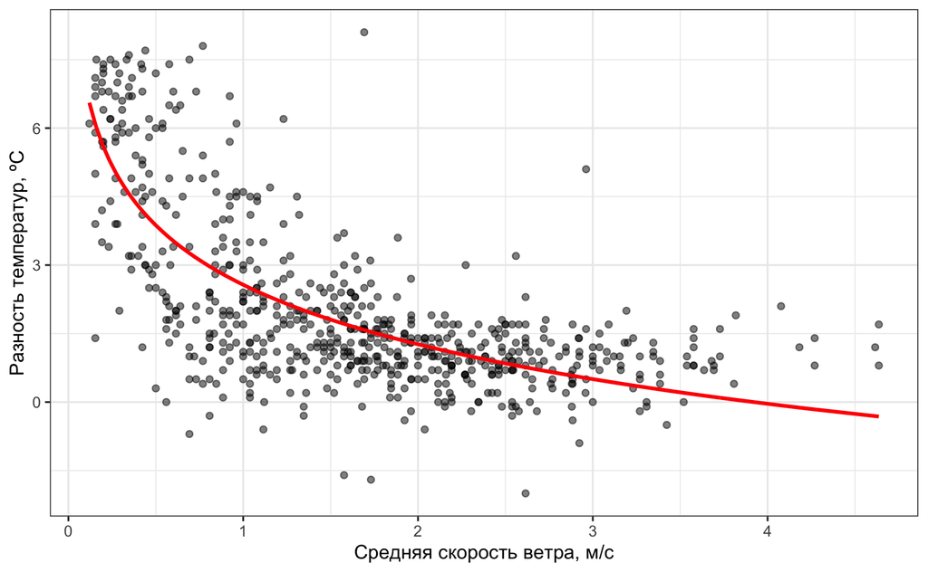

```r
mdl_df <- tibble(dT = fitted(my_mdl),
                 RegWspd = df_TW$RegWspd)

ggplot(df_TW, aes(x = RegWspd, y = dT)) +
  geom_point(alpha = 0.5) +
  geom_line(data = mdl_df, aes(RegWspd, dT), color = 'red', linewidth = 1) +
  theme_bw() +
  xlab('Средняя скорость ветра, м/с') +
  ylab('Разность температур, ºC')
```

Модель для ночной выборки:

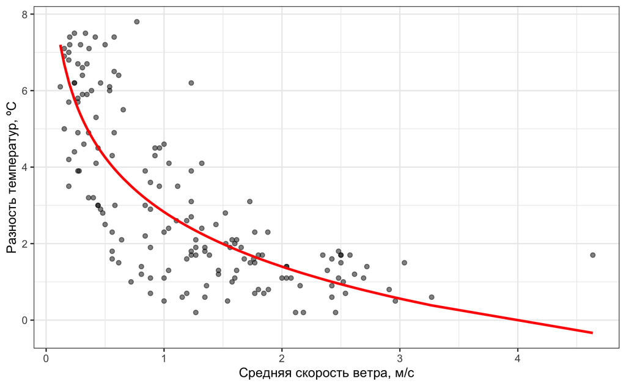

```r
mdl_df_night <- tibble(dT = fitted(my_mdl_night),
                 RegWspd = df_TW_night$RegWspd)

ggplot(df_TW_night, aes(x = RegWspd, y = dT)) +
  geom_point(alpha = 0.5) +
  geom_line(data = mdl_df_night, aes(RegWspd, dT),
            color = 'red', linewidth = 1) +
  theme_bw() +
  xlab('Средняя скорость ветра, м/с') +
  ylab('Разность температур, ºC')
```